# 13 Gain and Phase margins

Author

Affiliation

[Aditya Mahajan](https://adityam.github.io)

[McGill University](http://www.mcgill.ca/ece)

Updated

November 26, 2026

In practice, we never know the transfer function perfectly. So, it is important to understand the effect of model uncertainty on system stability. This is called the **robustness** of the stability of the system.

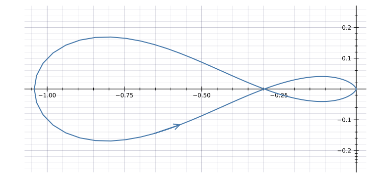

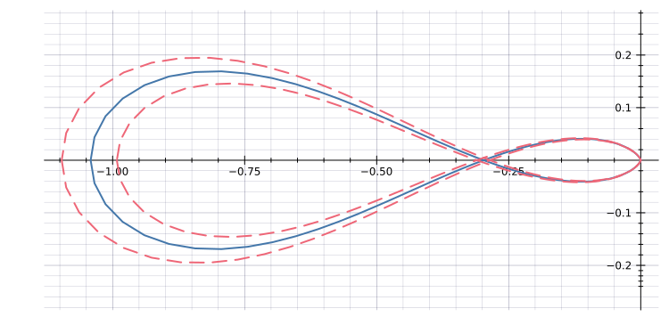

Figure 13.1: Nyquist plot with parameter uncertainty. The blue plot is the nominal Nyquist plot and the red curves show the envelop of uncertainty.

Using Nyquist plots, we can define two qualitative measures of how “close” the system is from unstability. The usual practice is to measure this closeness in terms of **gain margin (GM)** and **phase margin (PM)**.

In this section, we will restrict to minimal phase systems, that is systems that don’t have any poles or zeros in the ORHP. The general idea is that for a minimal phase system, the closer the Nyquist plot is to the $-1 + j0$ point, the closer the system is to unstability. So, we can use the closeness of $G(jω)$ to the $-1 + j0$ point as a measure of stability of the system.

The GM and PM are easier to compute proxies for the distance of $G(jω)$ from the $-1 + j0$ point. The reason that GM and PM are used as a proxy is that a minimal phase system is stable if and only if **both GM and PM are positive** (this can be inferred from Nyquist stability criterion). However, GM and PM are a crude proxy for robustness, but we will not study more nuanced techniques in this course.

## 13.1 The gain and phase margins

The **gain margin (GM)** is the factor by which the gain can be increased before the system becomes unstable. It is the reciprocal of the magnitude of $|G(jω)|$ at when the Nyquist plot intersects the negative real-axis.

Formally, let $ω_{\rm pc}$ denote the **phase crossover frequency**, i.e., the frequency at which $\angle G(jω) = -180^∘$ (so the Nyquist plot intersects the negative real-axis at $ω_{\rm pc}$. Then,
$$\text{GM} = \frac{1}{|G(jω_{\rm pc})|}$$
Typically, we express GM in decibels (dB), so
$$\text{GM} = - 20\log |G(jω_{\rm pc})|\, \text{dB}$$

The **phase margin (PM)** is the amount by which the phase can be increased before the system becomes unstable. It is the angle (as measured from the negative real-axis) at which the Nyquist plot intersects a circle of unit radium.

Formally, let $ω_{\rm gc}$ denote the **gain crossover frequency**, i.e., the frequency at which $|G(jω)| = 1$ (so the Nyquist plot intersects the unit circle at $ω_{\rm gc}$). Then,
$$\text{PM} = 180^∘ + \angle G(jω_{\rm gc})$$
For non-minimal phase systems, there may be multiple frequencies at which $|G(jω)|=1$ or $\angle G(jω) = 180^∘$. In such systems, we need to look at the highest and the lowest crossover frequencies. However, we will not study such systems in this course.

## 13.2 Some examples

Although GM and PM are defined based on Nyquist stability criterion, we will use Bode plots to determine them. We present some examples to show how to “read” GM and PM from the Bode plot.

**Example 13.1** Find the crossover frequencies and GM and PM of the following system:
$$G(s) = \dfrac{100}{s(s+1)(s+100)}$$
using the straight-line approximation Bode plots.

**NoteSolution**

We first draw the straight line approximation of the Bode plot.

**Bode plot**

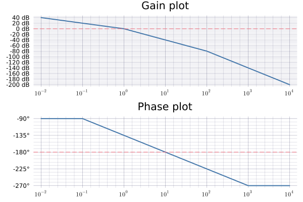

**GM-PM Calcs**

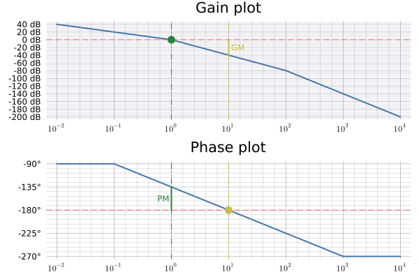

We first compute the GM. From the plot we see that the phase plot intersects the $-180 ^∘$ line at $ω_{\rm pc} = 10$ rad/s (the yellow circle). At $ω_{\rm pc} = 10$, we have $|G(j ω_{\rm pc})| = -40$ dB. Thus, ${\rm GM} = 40$ dB.

We now compute the PM. From the plot, we can see that the gain plot intersects the 0dB line at $ω = 1$ (the green circle). Thus, $ω_{\rm gc} = 1$ rad/s. At $ω_{\rm gc} = 1$, we have $\angle G(j ω_{\rm gc}) = -135 ^∘$. Thus, $\text{PM} = 180 ^∘ - 135 ^∘ = 45 ^∘$.

**Example 13.2** Find the crossover frequencies and GM and PM of the following system:
$$G(s) = \dfrac{10}{(s+1)(s+100)}$$
using the straight-line approximation Bode plots.

**NoteSolution**

We first draw the straight line approximation of the Bode plot.

**Bode plot**

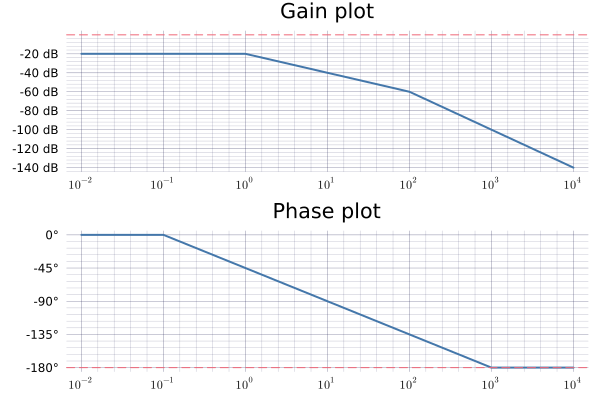

**GM-PM Calcs**

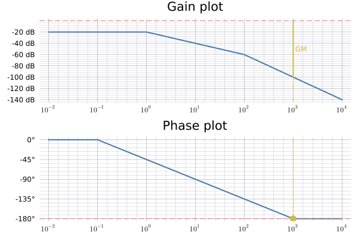

We first compute the GM. From the plot we see that the phase plot intersects the $-180 ^∘$ line at $ω_{\rm pc} = 10^3$ rad/s (the yellow point). At $ω_{\rm pc} = 10^3$, we have $|G(j ω_{\rm pc})| = -100$ dB. Thus, ${\rm GM} = 100$ dB.

We now compute the PM. From the plot, we can see that the gain plot does not intersect the 0dB line!. Thus, the PM is infinity.

**Note**: The above calculations are done using straight-line approximations. If we use the actual Bode plot, then the phase plot never actually reaches $-180 ^∘$, so the GM is also infinity. Nonetheless, in this course, we will only work with straight-line approximations.

**Example 13.3** Find the crossover frequencies and GM and PM of the following system:
$$G(s) = \dfrac{100}{(s+10)}$$
using the straight-line approximation Bode plots.

**NoteSolution**

We first draw the straight line approximation of the Bode plot.

**Bode plot**

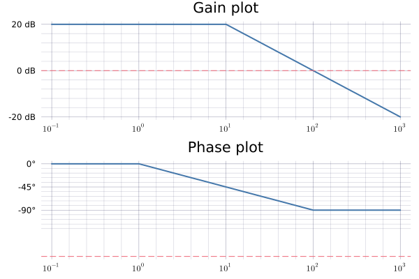

**GM-PM Calcs**

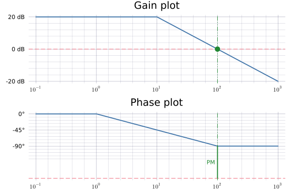

We first compute the GM. From the plot we see that the phase plot does not intersect the $-180 ^∘$. Therefore, the GM is infinity.

We now compute the PM. From the plot, we can see that the gain plot intersects the 0dB line at $ω = 10^2$. Thus, $ω_{\rm gc} = 10^2$ rad/s (the green circle). At $ω_{\rm gc} = 10^2$, we have $\angle G(j ω_{\rm gc}) = -90 ^∘$. Thus, $\text{PM} = 180 ^∘ - 90 ^∘ = 90 ^∘$.

## 13.3 Relationship between phase margin and damping ratio

We can relate the PM of an open loop system with the damping ratio of the unity feedback closed loop system. This enables us to evaluate the percentage overshoot of the closed loop system the PM of the open loop system.

[interactive chart not shown]

Figure 13.2: Phase margin as a function of damping ratio

Figure 13.2 shows that PM increases with damping ratio. Thus, increasing the PM makes the response less oscillatory.

**Example 13.4** Find the PM needed to ensure that the percentage overshoot is less than 10%.

**NoteSolution**

For percentage overshoot to be less than 10%, the damping coefficient must be larger than

$$ζ = \frac{- \ln(\%{\rm OS}/100)}{\sqrt{π^2 + \ln^2(\%{\rm OS}/100)}} = 0.5912$$

Looking at Figure 13.2, we see that $ζ \ge 0.59$ corresponds to $\text{PM} \ge 60^∘$. Thus, we need a PM of at least $60^∘$.